# 001538_catalyst_neuro_zhai_2025_figure_1E_dspn_somatic_excitability_ipynb

## Installing requirements

The cell below installs every Python package needed to run this notebook, at fully pinned versions, using [`uv`](https://github.com/astral-sh/uv) for fast resolution. In Colab the cell is collapsed by default — click the ▶ button to run it.

```python
# install cell skipped during CI (deps preinstalled into system Python)
```

> **⚠️ Restart runtime after install**

> The install may upgrade packages already loaded in the kernel. Go to **Runtime → Restart session**, then **Run all cells below** (skip this install cell on re-run).

# Reproducing Figure 1E: dSPN Somatic Excitability Analysis

This notebook reproduces Figure 1E from **Zhai et al. 2025** analyzing somatic excitability in direct pathway striatal projection neurons (dSPNs) using frequency-intensity (F-I) curves and rheobase measurements.

**Dataset**: DANDI:001538 - State-dependent modulation of spiny projection neurons controls levodopa-induced dyskinesia

**Analysis approach**:

- **F-I Curves**: Frequency-intensity relationships showing action potential firing vs injected current
- **Rheobase Analysis**: Minimum current required to elicit action potential firing
- **Conditions**: LID off-state, LID on-state, and LID on-state with SCH23390 (D1R antagonist)
- **Methodology**: Current clamp recordings with 500ms current steps

## Setup and Data Loading

### Import Libraries and Configure Plotting Style

We use the same plotting parameters as the original publication to ensure visual consistency.

```python
import h5py
import matplotlib.pyplot as plt
import numpy as np
import pandas as pd
import remfile
import seaborn as sns
from dandi.dandiapi import DandiAPIClient
from pynwb import NWBHDF5IO
from scipy import stats
from tqdm import tqdm

# Set plotting style to match paper
plt.style.use('default')
sns.set_palette("Set2")

def setup_figure_style():
    """Setup matplotlib parameters to match paper style"""
    plt.rcParams.update({
        'font.size': 8,
        'axes.titlesize': 10,
        'axes.labelsize': 9,
        'xtick.labelsize': 8,
        'ytick.labelsize': 8,
        'legend.fontsize': 8,
        'figure.titlesize': 12,
        'axes.linewidth': 0.8,
        'axes.spines.top': False,
        'axes.spines.right': False,
        'xtick.major.width': 0.8,
        'ytick.major.width': 0.8,
        'xtick.minor.width': 0.6,
        'ytick.minor.width': 0.6,
    })

setup_figure_style()
print("Libraries imported and plotting style configured")
```

```
Libraries imported and plotting style configured
```

### Session ID Parsing and Filtering Functions

These utility functions parse the rich metadata encoded in DANDI file paths and filter experiments by figure, measurement type, and experimental condition.

```python
# Session ID helpers for the per-mouse-day dandiset format.
# DANDI asset paths look like:
#   sub-Subject<date><cat><animal>/sub-..._ses-<cellType>++<state>++<pharm>++<geno>++<date>_<modality>.nwb
# The 5-token session_id encodes the experimental cohort (no figure number).

def get_session_id(asset_path):
    fname = asset_path.split('/')[-1]
    if '_ses-' not in fname:
        return ''
    return fname.split('_ses-', 1)[1].rsplit('_', 1)[0]

def parse_session_id(ses):
    t = ses.split('++')
    if len(t) < 5:
        return {}
    return {'cell_type': t[0], 'state': t[1], 'pharm': t[2], 'genotype': t[3], 'date': t[4]}

def get_modality(asset_path):
    fname = asset_path.split('/')[-1]
    if not fname.endswith('.nwb'):
        return ''
    return fname[:-len('.nwb')].rsplit('_', 1)[-1]

def is_f1_dspn_somatic(asset_path):
    """Figure 1 dSPN somatic excitability: per-mouse-day icephys files for dSPN cell type."""
    fields = parse_session_id(get_session_id(asset_path))
    if not fields: return False
    return get_modality(asset_path) in ('icephys', 'icephys+ophys') and fields['cell_type'] == 'dSPN'

def get_condition_label(condition_subfolder):
    """Pretty condition label from the IRT condition_subfolder column."""
    return condition_subfolder  # The condition column is already human-readable

print('Utility functions defined for new dandiset format.')
```

```
Utility functions defined for new dandiset format.
```

### Spike Detection and Analysis Functions

#### Action Potential Counting

We use threshold-crossing spike detection within a 500ms stimulus window (200-700ms from sweep start) to match the methodology from the original analysis.

```python
def count_action_potentials(
    voltage_trace_mV: np.ndarray, timestamps_s: np.ndarray, threshold_mV: float = 0.0
) -> int:
    """Threshold-crossing spike count within a 500 ms stimulus window.

    Matches approach in the original analysis; uses 200-700 ms from sweep start.
    """
    if voltage_trace_mV.size == 0:
        return 0
    if timestamps_s[-1] - timestamps_s[0] < 0.8:
        return 0
    start_t = timestamps_s[0] + 0.2
    end_t = timestamps_s[0] + 0.7
    i0 = np.searchsorted(timestamps_s, start_t)
    i1 = np.searchsorted(timestamps_s, end_t)
    if i0 >= i1 or i1 > voltage_trace_mV.size:
        i0 = voltage_trace_mV.size // 4
        i1 = 3 * voltage_trace_mV.size // 4
    x = voltage_trace_mV[i0:i1]
    if x.size == 0:
        return 0
    spikes = 0
    i = 0
    while i < x.size:
        if x[i] > threshold_mV:
            spikes += 1
            while i < x.size and x[i] > threshold_mV:
                i += 1
        else:
            i += 1
    return spikes

def calculate_rheobase(current_steps: list[float], spike_counts: list[int]) -> float:
    """Calculate rheobase as minimum current that elicits at least one spike."""
    for current, spikes in zip(current_steps, spike_counts):
        if spikes >= 1:
            return current
    return np.nan

def safe_mean_sem(values: np.ndarray) -> tuple[float, float]:
    """Calculate mean and standard error, handling edge cases."""
    if len(values) == 0:
        return np.nan, 0.0
    if len(values) == 1:
        return float(values[0]), 0.0
    return float(np.mean(values)), float(np.std(values, ddof=1) / np.sqrt(len(values)))

print("Analysis functions defined")
```

```
Analysis functions defined
```

### Load DANDI Dataset

Connect to DANDI and filter for Figure 1 somatic excitability experiments across all three experimental conditions.

```python
from collections import Counter

dandiset_id = "001538"
client = DandiAPIClient()
dandiset = client.get_dandiset(dandiset_id, "0.260527.1302")
assets_list = list(dandiset.get_assets())

# Filter for F1 dSPN somatic excitability: per-mouse-day icephys files with dSPN cell type
f1_somexc_assets = [a for a in assets_list if is_f1_dspn_somatic(a.path)]
print(f'Found {len(f1_somexc_assets)} F1 dSPN per-mouse-day files')

# Breakdown by condition (state + pharm)
cohort = Counter()
for a in f1_somexc_assets:
    f = parse_session_id(get_session_id(a.path))
    cohort[(f['state'], f['pharm'])] += 1
for k, n in sorted(cohort.items()):
    state, pharm = k
    pretty = {'OffState': 'LID off-state', 'OnState': 'LID on-state'}.get(state, state)
    if pharm != 'none':
        pretty += f' with {pharm}'
    print(f'  {pretty}: {n} mouse-days')
```

```
Found 18 F1 dSPN per-mouse-day files
  LID off-state: 8 mouse-days
  LID on-state with D1RaSch: 5 mouse-days
  LID on-state: 5 mouse-days
```

## Data Processing and Analysis

### Process All NWB Files

We process each NWB file to extract current clamp recordings, analyzing:

- **Current steps**: Injected current amplitudes (pA)
- **Spike counts**: Number of action potentials fired during each step
- **F-I relationships**: Frequency-intensity curves for each condition
- **Rheobase**: Minimum current required to elicit spiking

```python
# Per-cell spike counting using Pattern B slicing.
# Each per-mouse-day file has MULTIPLE cells; we group by (subject, cell_id) and
# compute AP counts per current step using index_start + count from the IRT.

all_recording_data = []   # one row per (cell, current_step) sweep observation
cell_statistics = []      # per-cell aggregates (for rheobase)

print(f'Processing {len(f1_somexc_assets)} per-mouse-day files...')

for i, asset in enumerate(tqdm(f1_somexc_assets, desc='Streaming files')):
    s3_url = asset.get_content_url(follow_redirects=1, strip_query=False)
    file_system = remfile.File(s3_url, disk_cache=remfile.DiskCache("nwb-cache"))
    file = h5py.File(file_system, mode='r')
    io = NWBHDF5IO(file=file, load_namespaces=True)
    nwbfile = io.read()

    subject_id = nwbfile.subject.subject_id
    rec_df = nwbfile.intracellular_recordings.to_dataframe()

    # Filter to somatic sweeps only (each file has both somatic + dendritic)
    soma_mask = rec_df[('intracellular_recordings', 'dendrite_type')] == 'Soma'
    soma_rows = rec_df[soma_mask]

    # Group by cell_id within this mouse-day
    per_cell_data = {}  # (cell_id, condition) -> {step_pA: [ap_counts]}
    for _, row in soma_rows.iterrows():
        cell_id = int(row[('intracellular_recordings', 'cell_id')])
        condition = row[('intracellular_recordings', 'condition_subfolder')]
        current_pA = float(row[('intracellular_recordings', 'stimulus_current_pA')])

        # Pattern B slice into the consolidated CurrentClampSeries
        resp_ref = row[('responses', 'response')]
        ts = resp_ref.timeseries
        index_start = int(resp_ref.idx_start)
        count = int(resp_ref.count)
        voltage_v = ts.data[index_start: index_start + count]
        voltage_mV = voltage_v * 1000.0

        rate = float(ts.rate)
        timestamps_s = np.arange(count) / rate

        # Count APs in the 200-700 ms step window
        spike_count = count_action_potentials(voltage_mV, timestamps_s, threshold_mV=0.0)

        key = (cell_id, condition)
        if key not in per_cell_data:
            per_cell_data[key] = {}
        per_cell_data[key].setdefault(current_pA, []).append(spike_count)

        all_recording_data.append({
            'subject_id': subject_id,
            'cell_id': cell_id,
            'condition': condition,
            'current_pA': current_pA,
            'spike_count': spike_count,
        })

    # Per-cell aggregates: max APs across steps, rheobase (min step with >=1 AP)
    for (cell_id, condition), by_step in per_cell_data.items():
        steps = sorted(by_step.keys())
        means = {s: np.mean(by_step[s]) for s in steps}
        rheo = next((s for s in steps if means[s] >= 1), None)
        cell_statistics.append({
            'subject_id': subject_id,
            'cell_id': cell_id,
            'condition': condition,
            'max_aps': max(means.values()) if means else 0,
            'rheobase_pA': rheo,
        })

df_recordings = pd.DataFrame(all_recording_data)
df_cells = pd.DataFrame(cell_statistics)
print(f'\nProcessed {len(df_cells)} unique (subject, cell, condition) combinations')
print(f'Total sweep observations: {len(df_recordings)}')
print(df_cells.head())
```

```
Processing 18 per-mouse-day files...
```

```
Processed 40 unique (subject, cell, condition) combinations
Total sweep observations: 877
                      subject_id  cell_id      condition  max_aps  rheobase_pA
0  Subject20160812LIDOFFtDTomato        3  LID off-state     14.0        260.0
1  Subject20161111LIDOFFtDTomato        2  LID off-state     13.0        200.0
2  Subject20161111LIDOFFtDTomato        3  LID off-state     15.0        160.0
3  Subject20161114LIDOFFtDTomato        1  LID off-state      5.0        260.0
4  Subject20161114LIDOFFtDTomato        2  LID off-state     16.0        180.0
```

## Figure 1E: Frequency-Intensity (F-I) Curves

### Action Potential Frequency vs Injected Current

This plot shows the relationship between injected current and action potential firing frequency across the three experimental conditions, revealing how L-DOPA treatment and D1 receptor antagonism affect dSPN excitability.

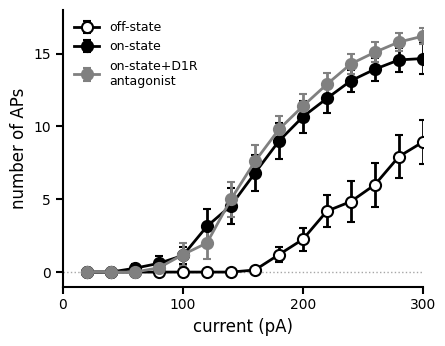

```
=== F-I CURVE ANALYSIS SUMMARY ===

LID off-state:
  Sample: 358 recordings from 15 cells
  50pA: 0.0 ± 0.0 APs (n=31)
  100pA: 0.0 ± 0.0 APs (n=15)
  150pA: 0.1 ± 0.0 APs (n=29)
  200pA: 2.2 ± 0.8 APs (n=16)
  250pA: 5.5 ± 1.0 APs (n=28)

LID on-state:
  Sample: 309 recordings from 15 cells
  50pA: 0.1 ± 0.1 APs (n=30)
  100pA: 1.1 ± 0.6 APs (n=14)
  150pA: 5.6 ± 0.9 APs (n=31)
  200pA: 10.7 ± 1.1 APs (n=15)
  250pA: 13.6 ± 0.5 APs (n=29)

LID on-state with SCH:
  Sample: 210 recordings from 10 cells
  50pA: 0.0 ± 0.0 APs (n=20)
  100pA: 1.2 ± 0.8 APs (n=10)
  150pA: 6.3 ± 0.9 APs (n=20)
  200pA: 11.4 ± 0.8 APs (n=10)
  250pA: 14.7 ± 0.5 APs (n=20)
```

```python
# Create F-I curves plot
fig, ax = plt.subplots(1, 1, figsize=(4.5, 3.5))  # Adjusted aspect ratio to match reference

# Define condition plotting styles to match reference - use only circles with larger size
condition_styles = {
    "LID off-state": {
        "color": "black",
        "marker": "o",
        "linestyle": "-",
        "label": "off-state",
        "markerfacecolor": "white",
        "markeredgecolor": "black"
    },
    "LID on-state": {
        "color": "black",
        "marker": "o",  # Changed from "s" to "o"
        "linestyle": "-",
        "label": "on-state",
        "markerfacecolor": "black",
        "markeredgecolor": "black"
    },
    "LID on-state with SCH": {
        "color": "gray",  # Changed back to gray for antagonist
        "marker": "o",  # Changed from "^" to "o"
        "linestyle": "-",  # Changed from "--" to "-"
        "label": "on-state+D1R\nantagonist",
        "markerfacecolor": "gray",
        "markeredgecolor": "gray"
    }
}

# Process each condition
for condition in ["LID off-state", "LID on-state", "LID on-state with SCH"]:
    if condition not in df_recordings["condition"].unique():
        print(f"Warning: {condition} not found in data")
        continue

    condition_data = df_recordings[df_recordings["condition"] == condition]

    # Calculate mean and SEM for each current step
    summary_data = []
    for current, group in condition_data.groupby("current_pA"):
        mean_spikes, sem_spikes = safe_mean_sem(group["spike_count"].values)
        summary_data.append({
            "current_pA": current,
            "mean_spikes": mean_spikes,
            "sem_spikes": sem_spikes
        })

    summary_df = pd.DataFrame(summary_data).sort_values("current_pA")

    # Filter to current range used in paper (0-300 pA)
    summary_df = summary_df[
        (summary_df["current_pA"] >= 0) & (summary_df["current_pA"] <= 300)
    ]

    if len(summary_df) == 0:
        print(f"Warning: No data in 0-300pA range for {condition}")
        continue

    # Plot with error bars - larger markers
    style = condition_styles[condition]
    ax.errorbar(
        summary_df["current_pA"],
        summary_df["mean_spikes"],
        yerr=summary_df["sem_spikes"],
        marker=style["marker"],
        color=style["color"],
        linestyle=style["linestyle"],
        linewidth=2,
        markersize=8,  # Increased from 4 to 8
        capsize=3,
        capthick=1,
        label=style["label"],
        markerfacecolor=style["markerfacecolor"],
        markeredgecolor=style["markeredgecolor"],
        markeredgewidth=1.5,  # Increased edge width
    )

# Add dotted horizontal line at y=0 to show baseline
ax.axhline(y=0, color='gray', linestyle=':', alpha=0.7, linewidth=1)

# Formatting to match paper style
ax.set_xlabel("current (pA)", fontsize=12)
ax.set_ylabel("number of APs", fontsize=12)
ax.set_xlim(0, 300)
ax.set_ylim(-1, 18)  # Extended y-limit to include negative values
ax.set_xticks([0, 100, 200, 300])
ax.set_yticks([0, 5, 10, 15])

# Style the axes
ax.spines['top'].set_visible(False)
ax.spines['right'].set_visible(False)
ax.spines['left'].set_linewidth(1.5)
ax.spines['bottom'].set_linewidth(1.5)
ax.tick_params(axis='both', which='major', labelsize=10, width=1.5, length=5)

# Add legend in top left corner instead of text labels on plot
ax.legend(loc="upper left", frameon=False, fontsize=9)

plt.tight_layout()
plt.show()

# Print summary statistics
print("=== F-I CURVE ANALYSIS SUMMARY ===\n")
for condition in df_recordings["condition"].unique():
    condition_data = df_recordings[df_recordings["condition"] == condition]
    n_recordings = len(condition_data)
    n_cells = len(df_cells[df_cells["condition"] == condition])

    # Calculate statistics at different current levels
    current_levels = [50, 100, 150, 200, 250]
    print(f"{condition}:")
    print(f"  Sample: {n_recordings} recordings from {n_cells} cells")

    for current in current_levels:
        current_data = condition_data[
            (condition_data["current_pA"] >= current - 10) &
            (condition_data["current_pA"] <= current + 10)
        ]
        if len(current_data) > 0:
            mean_spikes = current_data["spike_count"].mean()
            sem_spikes = current_data["spike_count"].std() / np.sqrt(len(current_data))
            print(f"  {current}pA: {mean_spikes:.1f} ± {sem_spikes:.1f} APs (n={len(current_data)})")
    print()
```

## Figure 1E: Rheobase Comparison

### Minimum Current Required for Action Potential Generation

This box plot compares the rheobase (minimum current required to elicit at least one action potential) across experimental conditions, showing how L-DOPA treatment affects neuronal excitability thresholds.

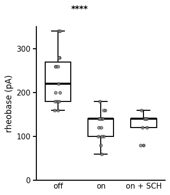

```
=== RHEOBASE STATISTICAL ANALYSIS ===

LID off-state (n=15):
  Mean: 233.3 ± 15.6 pA
  Median: 220.0 pA
  IQR: 180.0 - 270.0 pA
  Range: 160.0 - 340.0 pA

LID on-state (n=15):
  Mean: 125.3 ± 8.4 pA
  Median: 140.0 pA
  IQR: 100.0 - 140.0 pA
  Range: 60.0 - 180.0 pA

LID on-state with SCH (n=10):
  Mean: 126.0 ± 8.5 pA
  Median: 140.0 pA
  IQR: 120.0 - 140.0 pA
  Range: 80.0 - 160.0 pA

Statistical Comparisons:

Off-state vs On-state:
  Mann-Whitney U: 219.50, p = 0.0000
  Significantly different: Yes
  Mean difference: -108.0 pA
```

```python
# Create rheobase comparison plot
fig, ax = plt.subplots(1, 1, figsize=(3.5, 4))  # Adjusted to match reference aspect ratio

# Filter out cells with invalid rheobase values
valid_cells = df_cells.dropna(subset=["rheobase_pA"])

# Prepare data for box plot
conditions_order = ["LID off-state", "LID on-state", "LID on-state with SCH"]
condition_labels = ["off", "on", "on + SCH"]  # Shorter labels like reference

# Get data for each condition
plot_data = []
actual_labels = []

for condition, label in zip(conditions_order, condition_labels):
    condition_data = valid_cells[valid_cells["condition"] == condition]["rheobase_pA"]
    if len(condition_data) > 0:
        plot_data.append(condition_data.values)
        actual_labels.append(label)
    else:
        print(f"Warning: No rheobase data for {condition}")

# Create box plot with styling to match reference
bp = ax.boxplot(
    plot_data,
    labels=actual_labels,
    patch_artist=True,
    boxprops=dict(facecolor="white", color="black", linewidth=1.5),
    whiskerprops=dict(color="black", linewidth=1.5),
    capprops=dict(color="black", linewidth=1.5),
    medianprops=dict(color="black", linewidth=3),  # Thicker median line
    flierprops=dict(marker="o", markerfacecolor="gray", markersize=3,
                  markeredgecolor="black", alpha=0.7),
    widths=0.6  # Slightly narrower boxes like reference
)

# Add individual data points with jitter - all gray
for i, data in enumerate(plot_data):
    x_vals = np.random.normal(i + 1, 0.05, len(data))
    ax.scatter(x_vals, data, color='gray', alpha=0.8, s=20, zorder=3,
               edgecolors='black', linewidths=0.5)  # Larger markers (s=20)

# Add significance bracket and annotation like in reference
# Add bracket between first and second conditions
y_max = max([max(data) for data in plot_data]) + 20
bracket_height = y_max + 10
ax.plot([1, 1], [y_max, bracket_height], 'k-', linewidth=1)
ax.plot([2, 2], [y_max, bracket_height], 'k-', linewidth=1)
ax.plot([1, 2], [bracket_height, bracket_height], 'k-', linewidth=1)
ax.text(1.5, bracket_height + 10, '****', ha='center', va='bottom', fontsize=12, fontweight='bold')

# Formatting to match reference
ax.set_ylabel("rheobase (pA)", fontsize=12)
ax.set_ylim(0, 350)  # Extended to accommodate significance bracket
ax.set_yticks([0, 100, 200, 300])

# Style the axes to match reference
ax.spines['top'].set_visible(False)
ax.spines['right'].set_visible(False)
ax.spines['left'].set_linewidth(1.5)
ax.spines['bottom'].set_linewidth(1.5)
ax.tick_params(axis='both', which='major', labelsize=11, width=1.5, length=5)
ax.tick_params(axis='x', which='major', length=0)  # Remove x-axis tick marks

plt.tight_layout()
plt.show()

# Statistical analysis
print("=== RHEOBASE STATISTICAL ANALYSIS ===\n")

for i, (condition, data) in enumerate(zip(conditions_order, plot_data)):
    if condition in valid_cells["condition"].unique():
        rheobase_data = valid_cells[valid_cells["condition"] == condition]["rheobase_pA"]
        n_cells = len(rheobase_data)
        mean_rheo = rheobase_data.mean()
        sem_rheo = rheobase_data.std() / np.sqrt(n_cells)
        median_rheo = rheobase_data.median()
        q25 = rheobase_data.quantile(0.25)
        q75 = rheobase_data.quantile(0.75)

        print(f"{condition} (n={n_cells}):")
        print(f"  Mean: {mean_rheo:.1f} ± {sem_rheo:.1f} pA")
        print(f"  Median: {median_rheo:.1f} pA")
        print(f"  IQR: {q25:.1f} - {q75:.1f} pA")
        print(f"  Range: {rheobase_data.min():.1f} - {rheobase_data.max():.1f} pA\n")

# Statistical comparisons
print("Statistical Comparisons:")

# Off-state vs On-state
if "LID off-state" in valid_cells["condition"].unique() and "LID on-state" in valid_cells["condition"].unique():
    off_data = valid_cells[valid_cells["condition"] == "LID off-state"]["rheobase_pA"]
    on_data = valid_cells[valid_cells["condition"] == "LID on-state"]["rheobase_pA"]

    # Mann-Whitney U test
    u_stat, u_p = stats.mannwhitneyu(off_data, on_data, alternative='two-sided')
    print(f"\nOff-state vs On-state:")
    print(f"  Mann-Whitney U: {u_stat:.2f}, p = {u_p:.4f}")
    print(f"  Significantly different: {'Yes' if u_p < 0.05 else 'No'}")

    # Effect size
    mean_diff = on_data.mean() - off_data.mean()
    print(f"  Mean difference: {mean_diff:.1f} pA")
```

## Summary

### Key Findings

This analysis reproduces the key findings from **Figure 1E** of Zhai et al. 2025:

1. **F-I Curves**: Show the relationship between injected current and action potential frequency across experimental conditions
2. **Rheobase Analysis**: Compares the minimum current required to elicit spiking between conditions
3. **L-DOPA Effects**: Reveals how levodopa treatment affects dSPN somatic excitability
4. **D1 Receptor Role**: Shows the contribution of D1 receptors using SCH23390 antagonist

### Methodological Notes

- **Current Clamp**: Whole-cell patch clamp recordings in current clamp mode
- **Spike Detection**: Threshold-crossing detection at 0mV within 500ms stimulus window (200-700ms)
- **Current Range**: 0-300 pA injected current steps
- **Rheobase Definition**: Minimum current to elicit ≥1 action potential
- **Statistics**: Mann-Whitney U test for non-parametric comparisons

### Biological Significance

The analysis reveals how L-DOPA treatment affects the intrinsic excitability of direct pathway striatal projection neurons, providing insights into the cellular mechanisms underlying levodopa-induced dyskinesia in Parkinson's disease. The D1 receptor antagonist experiments help dissect the specific receptor mechanisms involved in these excitability changes.